# simon and schuster data challenge

```python
import pandas as pd
from datetime import date
import matplotlib.pyplot as plt
from matplotlib import figure
import numpy as np
from scipy import stats
import seaborn as sns

import warnings
warnings.filterwarnings('ignore')

from sklearn.feature_selection import SelectKBest
from sklearn.feature_selection import chi2

import math
import keras
from keras.models import Sequential
from keras.layers import Dense
from keras.layers import LSTM
from keras.layers import Dropout
from keras.layers import *
from sklearn.preprocessing import MinMaxScaler
from sklearn.metrics import mean_squared_error
from sklearn.metrics import mean_absolute_error
from keras.callbacks import EarlyStopping
```

```python
df = pd.read_csv("/Users/apple/Downloads/sample_data.csv", encoding = "ISO-8859-1")
df.head()
```

|  | entity | formattype | fromdate | titlecount | titles | todate | author | amazontotalreviews | minappleprice | amazontotalrevenue | ... | lumpedpreorderrevenue | amazonsoldunits | amazonpreordersubscriptionrevenue | preordersubscriptionunits | amazonpreordersalesrevenue | maxappleprice | pagelength | pricewassetbypublisher | barnesandnobledistributor | appledistributor |
| --- | --- | --- | --- | --- | --- | --- | --- | --- | --- | --- | --- | --- | --- | --- | --- | --- | --- | --- | --- | --- | --- |
| 0 | Alone in the dark | print | 20170418 | 1 | {'amazontotalreviews': 306, 'minappleprice': 0... | 20170419 | Frith Banbury | 306.0 | 0 | 0 | ... | 0 | 6 | 0 | 0 | 0 | 0 | NaN | NaN | NaN | NaN |
| 1 | Alone in the dark | print | 20170419 | 1 | {'amazontotalreviews': 306, 'minappleprice': 0... | 20170420 | Frith Banbury | 306.0 | 0 | 702 | ... | 0 | 7 | 0 | 0 | 0 | 0 | NaN | NaN | NaN | NaN |
| 2 | Alone in the dark | print | 20170420 | 1 | {'amazontotalreviews': 306, 'minappleprice': 0... | 20170421 | Frith Banbury | 306.0 | 0 | 4914 | ... | 0 | 7 | 0 | 0 | 0 | 0 | NaN | NaN | NaN | NaN |
| 3 | Alone in the dark | print | 20170421 | 1 | {'amazontotalreviews': 306, 'minappleprice': 0... | 20170422 | Frith Banbury | 306.0 | 0 | 4212 | ... | 0 | 6 | 0 | 0 | 0 | 0 | NaN | NaN | NaN | NaN |
| 4 | Alone in the dark | print | 20170422 | 1 | {'amazontotalreviews': 306, 'minappleprice': 0... | 20170423 | Frith Banbury | 306.0 | 0 | 702 | ... | 0 | 1 | 0 | 0 | 0 | 0 | NaN | NaN | NaN | NaN |

5 rows × 106 columns

```python
df.nunique()
```

```
entity                                        2
formattype                                    3
fromdate                                    875
titlecount                                    4
titles                                     3976
todate                                      875
author                                        2
amazontotalreviews                          151
minappleprice                                 2
amazontotalrevenue                         1826
accruedpreordersoldunits                     35
amazonlumpedpreordersubscriptionrevenue       1
preordersalesrevenue                          3
foundatamazon                                 2
barnesandnobleaccruedpreorderrevenue          1
amazonpreordersubscriptionunits               1
amazonlumpedpreordersalesrevenue              3
foundatbarnesandnoble                         2
maxprice                                    331
lumpedpreordersubscriptionunits               1
applepreorderrevenue                          1
amazontotalunits                            213
totalrevenue                               1953
barnesandnobleaccruedpreorderunits            1
preorderunits                                 3
amazonsubscriptionrevenue                    41
amazonlumpedpreorderrevenue                   3
maxbarnesandnoblelistprice                    1
maxlistprice                                205
barnesandnoblesoldunits                       2
                                           ...
lumpedpreorderunits                           3
amazonaccruedpreordersubscriptionunits        1
formats                                      14
applepreorderunits                            1
subscriptionrevenue                          41
soldunits                                   216
minapplelistprice                             1
barnesandnoblepreorderrevenue                 1
amazonsubscriptionunits                      41
amazonlumpedpreordersubscriptionunits         1
aapreported                                   2
accruedpreordersubscriptionrevenue            1
foundatapple                                  2
barnesandnoblelumpedpreorderrevenue           1
barnesandnoblelumpedpreorderunits             1
minbarnesandnobleprice                        3
accruedpreordersalesrevenue                  36
maxbarnesandnobleprice                        3
preorderrevenue                               3
pubtrackreported                              2
lumpedpreorderrevenue                         3
amazonsoldunits                             212
amazonpreordersubscriptionrevenue             1
preordersubscriptionunits                     1
amazonpreordersalesrevenue                    3
maxappleprice                                 2
pagelength                                    6
pricewassetbypublisher                        1
barnesandnobledistributor                     1
appledistributor                              2
Length: 106, dtype: int64
```

## DATA EXPLORATION

First of I could see that there are two entities and three formats. I wanted to see how the data is classified based on this.

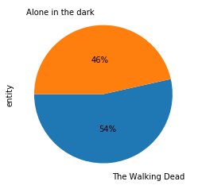

```python
pie = df['entity'].value_counts().plot(kind='pie',autopct='%1.0f%%', pctdistance=0.5, labeldistance=1.2, startangle=180)
```

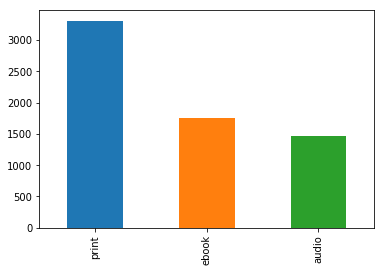

```python
bar = df['formattype'].value_counts().plot(kind='bar')
```

- I am converting the three columns with dates into date format.
- I am setting to date as index. This could make it easier to plot

```python
df['fromdate']= df['fromdate'].apply(lambda x: pd.to_datetime(str(x), format='%Y%m%d'))
df['todate']= df['todate'].apply(lambda x: pd.to_datetime(str(x), format='%Y%m%d'))
df['datepublished']= pd.to_datetime(df['datepublished'], infer_datetime_format=True)
```

```python
df.index = df['todate']
```

- I wanted to explore total revenue amongst the two entitites and the three format types.
- I see there are three main revenue generators - amazon, apple and barnes&nobels, so I plot sales revenue for each based on entity

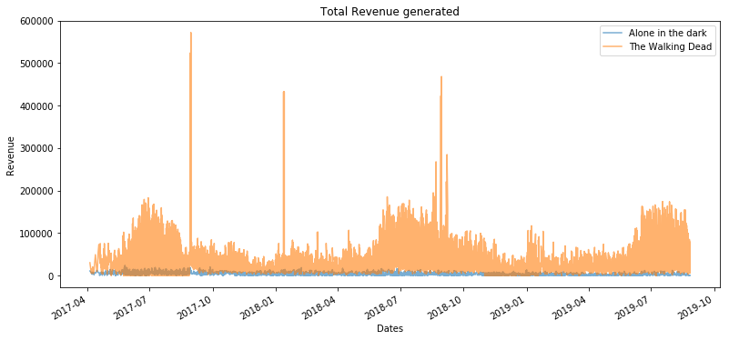

```python
total_revenue = df.groupby('entity')['totalrevenue'].plot(legend=True ,alpha = 0.6, figsize=(13,6))
total_revenue = plt.ylabel('Revenue')
total_revenue = plt.xlabel('Dates')
total_revenue = plt.title('Total Revenue generated')
```

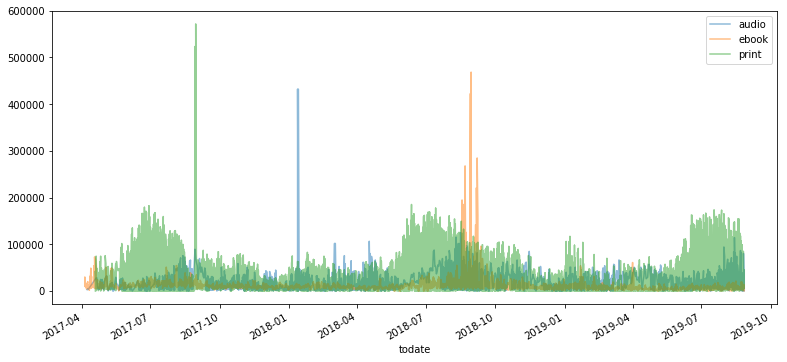

```python
total_revenue_byformat = df.groupby('formattype')['totalrevenue'].plot(legend=True ,alpha = 0.5, figsize=(13,6))
```

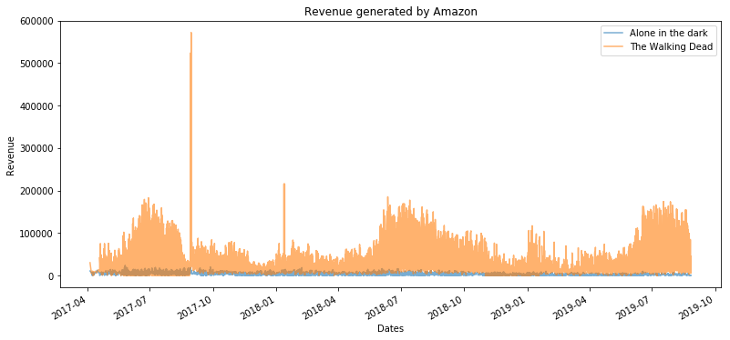

```python
amazon_sales = df.groupby('entity')['amazonsalesrevenue'].plot(legend=True ,alpha = 0.6, figsize=(13,6))
amazon_sales = plt.ylabel('Revenue')
amazon_sales = plt.xlabel('Dates')
amazon_sales = plt.title('Revenue generated by Amazon')
```

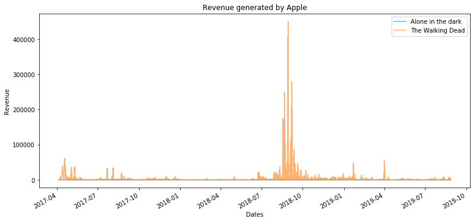

```python
apple_sales = df.groupby('entity')['applesalesrevenue'].plot(legend=True, alpha = 0.6, figsize=(13,6))
apple_sales  = plt.ylabel('Revenue')
apple_sales  = plt.xlabel('Dates')
apple_sales  = plt.title('Revenue generated by Apple')
```

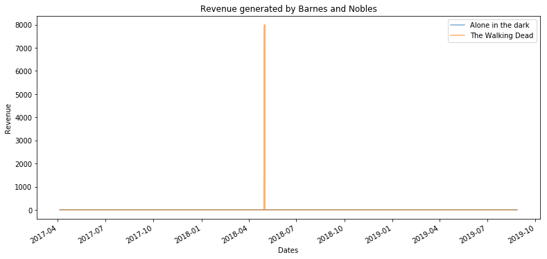

```python
barnesandnobles_sales = df.groupby('entity')['barnesandnoblesalesrevenue'].plot(legend=True, alpha = 0.6, figsize=(13,6))
barnesandnobles_sales  = plt.ylabel('Revenue')
barnesandnobles_sales  = plt.xlabel('Dates')
barnesandnobles_sales  = plt.title('Revenue generated by Barnes and Nobles')
```

### Conclusions

- Walking dead generated the most revenue. Books were mostly bought.
- In case of amazon, Alone in the Dark sales were constant and did not contribute to revenue on the other hand for walking dead it saw occational spikes.
- For apple's and Barnes and Nobles revenue, all its sales were from The walking dead.
- Out of curiosity, I looked up what were these spikes were about, Funnily there were not because of the book release, but they were before the release of The Walking Dead new season.

## FEATURE SELECTION

To see which features played a big roles in predicting the total revenue.

### Data Cleaning

```python
dff = df.loc[:, df.isin([0]).mean() < .8]
dff = dff.drop(['titles', 'amazoncategories','fromdate','datepublished','author','publishertype',
                'pubtrackreported','pagelength','pricewassetbypublisher','barnesandnobledistributor',
                'appledistributor','publisherparent','todate'], axis=1)
```

```python
dff.head()
```

| todate | entity | formattype | titlecount | amazontotalreviews | amazontotalrevenue | foundatamazon | foundatbarnesandnoble | maxprice | amazontotalunits | totalrevenue | ... | maxamazonprice | amazonaveragerating | amazonsalesrevenue | minlistprice | minamazonprice | salesrevenue | formats | soldunits | aapreported | amazonsoldunits |
| --- | --- | --- | --- | --- | --- | --- | --- | --- | --- | --- | --- | --- | --- | --- | --- | --- | --- | --- | --- | --- | --- |
| 2017-04-19 | Alone in the dark | print | 1 | 306.0 | 0 | 1 | 0 | 0 | 6 | 0 | ... | 0 | 410.0 | 0 | 0 | 0 | 0 | Audio CD | 6 | 1 | 6 |
| 2017-04-20 | Alone in the dark | print | 1 | 306.0 | 702 | 1 | 0 | 702 | 7 | 702 | ... | 702 | 410.0 | 702 | 0 | 0 | 702 | Audio CD | 7 | 1 | 7 |
| 2017-04-21 | Alone in the dark | print | 1 | 306.0 | 4914 | 1 | 0 | 702 | 7 | 4914 | ... | 702 | 410.0 | 4914 | 702 | 702 | 4914 | Audio CD | 7 | 1 | 7 |
| 2017-04-22 | Alone in the dark | print | 1 | 306.0 | 4212 | 1 | 0 | 702 | 6 | 4212 | ... | 702 | 410.0 | 4212 | 702 | 702 | 4212 | Audio CD | 6 | 1 | 6 |
| 2017-04-23 | Alone in the dark | print | 1 | 306.0 | 702 | 1 | 0 | 702 | 1 | 702 | ... | 702 | 410.0 | 702 | 702 | 702 | 702 | Audio CD | 1 | 1 | 1 |

5 rows × 26 columns

```python
# getting dummy values
dff = pd.get_dummies(dff)
```

- I spilt the data frame to predicting variables and response variable

```python
X = dff.loc[:, dff.columns != 'totalrevenue']
y =dff.loc[:, dff.columns == 'totalrevenue']
y.head()
```

| todate | totalrevenue |
| --- | --- |
| 2017-04-19 | 0 |
| 2017-04-20 | 702 |
| 2017-04-21 | 4914 |
| 2017-04-22 | 4212 |
| 2017-04-23 | 702 |

```python
#Replacing null values with mean
X = X.fillna(X.mean())
y = y.fillna(y.mean())
```

- Method 1 - Univarite approach: The features are selected based on chi-scores

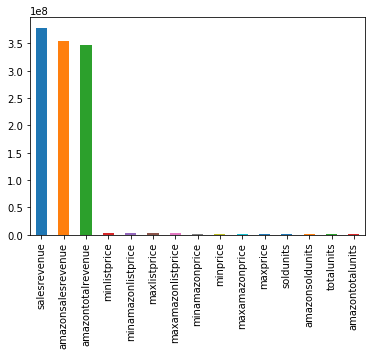

```python
bestfeatures = SelectKBest(score_func=chi2, k=10)
fit = bestfeatures.fit(X,y)
dfscores = pd.DataFrame(fit.scores_)
dfcolumns = pd.DataFrame(X.columns)
feature_scores = pd.Series(fit.scores_ , index = X.columns)
feature_scores.nlargest(15).plot(kind='bar')
plt.show()
```

- Method 2 - Feature importance using tree classifers

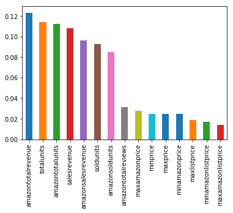

```python
from sklearn.ensemble import ExtraTreesClassifier
model = ExtraTreesClassifier()
model.fit(X,y)
#print(model.feature_importances_)
feat_importances = pd.Series(model.feature_importances_, index=X.columns)
feat_importances.nlargest(15).plot(kind='bar')
plt.show()
```

### Conclusions

- In both the cases sales amazon revenue is one of the top feature, but that was pretty obivious as most of the total revenue came from amazon.
- Units sold and sales revenue is again directly proportional to total revenue.

## LONG SHORT TERM MEMORY

Since Walking dead produced the most revenue, I choose to forecast the revenue for The Walking Dead using LSTM.

### Data Preparation

- Taking the only the todate and total revenue columns, where is entity is The Walking Dead
- There were 9 records with total revenue greater than 200000.I removed those records as they were acting as outliers.

```python
entity_2 = df[df['entity'] == 'The Walking Dead']
walking_dead  = entity_2[['totalrevenue','todate']]

walking_dead.shape
walking_dead.head()
```

| todate | totalrevenue | todate |
| --- | --- | --- |
| 2017-04-19 | 42616 | 2017-04-19 |
| 2017-04-20 | 74578 | 2017-04-20 |
| 2017-04-21 | 48704 | 2017-04-21 |
| 2017-04-22 | 34245 | 2017-04-22 |
| 2017-04-23 | 39572 | 2017-04-23 |

```python
#Removing outliers
walking_dead = walking_dead[(walking_dead['totalrevenue'] < 200000)]
```

### Checking for Stationarity

First step in time series forecasting is to check if the data is stationary or not. I used three approches to check -

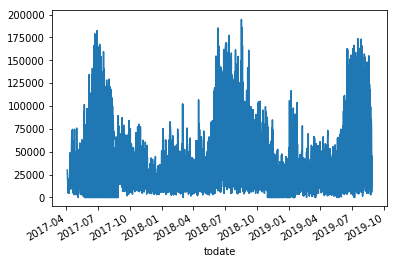

```python
#approach 1
walking_dead['totalrevenue'].plot()
```

```python
#approach 2
from statsmodels.tsa.stattools import adfuller
def adf_test(timeseries):
    #Perform Dickey-Fuller test:
    print ('Results of Dickey-Fuller Test:')
    dftest = adfuller(timeseries, autolag='AIC')
    dfoutput = pd.Series(dftest[0:4], index=['Test Statistic','p-value','#Lags Used','Number of Observations Used'])
    for key,value in dftest[4].items():
       dfoutput['Critical Value (%s)'%key] = value
    print (dfoutput)

#apply adf test on the series
adf_test(walking_dead['totalrevenue'])
```

```
Results of Dickey-Fuller Test:
Test Statistic                   -3.900878
p-value                           0.002028
#Lags Used                       27.000000
Number of Observations Used    3462.000000
Critical Value (1%)              -3.432240
Critical Value (5%)              -2.862375
Critical Value (10%)             -2.567215
dtype: float64
```

```python
#approach 3
from statsmodels.tsa.stattools import kpss
#define KPSS
def kpss_test(timeseries):
    print ('Results of KPSS Test:')
    kpsstest = kpss(timeseries, regression='c')
    kpss_output = pd.Series(kpsstest[0:3], index=['Test Statistic','p-value','Lags Used'])
    for key,value in kpsstest[3].items():
        kpss_output['Critical Value (%s)'%key] = value
    print (kpss_output)

kpss_test(walking_dead['totalrevenue'])
```

```
Results of KPSS Test:
Test Statistic            1.08846
p-value                   0.01000
Lags Used                30.00000
Critical Value (10%)      0.34700
Critical Value (5%)       0.46300
Critical Value (2.5%)     0.57400
Critical Value (1%)       0.73900
dtype: float64
```

- since the data is not stationary, I am differencing with the consecutive terms

| todate | totalrevenue | todate | totalrevenue_diff |
| --- | --- | --- | --- |
| 2017-04-19 | 42616 | 2017-04-19 | NaN |
| 2017-04-20 | 74578 | 2017-04-20 | 31962.0 |
| 2017-04-21 | 48704 | 2017-04-21 | -25874.0 |
| 2017-04-22 | 34245 | 2017-04-22 | -14459.0 |
| 2017-04-23 | 39572 | 2017-04-23 | 5327.0 |

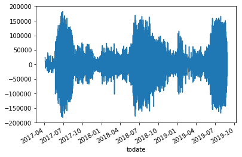

```python
walking_dead['totalrevenue_diff'] = walking_dead['totalrevenue'] - walking_dead['totalrevenue'].shift(1)
walking_dead['totalrevenue_diff'].plot()
walking_dead.head()
```

```python
#Removing null values
walking_dead = walking_dead.dropna()
```

### Modelling

- Create the dataset, ensure all data is float.
- Normalize the features.
- Split into training and test sets.
- Convert an array of values into a dataset matrix.
- Reshape into X=t and Y=t+1.
- Reshape input to be 3D (num_samples, num_timesteps, num_features).

```python
dataset = walking_dead.totalrevenue_diff.values #numpy.ndarray
dataset = dataset.astype('float32')
dataset = np.reshape(dataset, (-1, 1))
scaler = MinMaxScaler(feature_range=(0, 1))
dataset = scaler.fit_transform(dataset)
train_size = int(len(dataset) * 0.80)
test_size = len(dataset) - train_size
train, test = dataset[0:train_size,:], dataset[train_size:len(dataset),:]

def create_dataset(dataset, look_back=1):
    X, Y = [], []
    for i in range(len(dataset)-look_back-1):
        a = dataset[i:(i+look_back), 0]
        X.append(a)
        Y.append(dataset[i + look_back, 0])
    return np.array(X), np.array(Y)

look_back = 7
X_train, Y_train = create_dataset(train, look_back)
X_test, Y_test = create_dataset(test, look_back)

# reshape input to be [samples, time steps, features]
X_train = np.reshape(X_train, (X_train.shape[0], 1, X_train.shape[1]))
X_test = np.reshape(X_test, (X_test.shape[0], 1, X_test.shape[1]))
```

```python
model = Sequential()
model.add(LSTM(4,input_shape=(X_train.shape[1], X_train.shape[2])))
model.add(Dense(1))
model.compile(loss='mean_squared_error', optimizer='adam')

history = model.fit(X_train, Y_train, epochs=24, batch_size=13, validation_data=(X_test, Y_test),
                    callbacks=[EarlyStopping(monitor='val_loss', patience=20)], verbose=1, shuffle=False)

model.summary()
```

```
Train on 2783 samples, validate on 690 samples
Model: "sequential_85"
_________________________________________________________________
Layer (type)                 Output Shape              Param #
=================================================================
lstm_82 (LSTM)               (None, 4)                 192
_________________________________________________________________
dense_81 (Dense)             (None, 1)                 5
=================================================================
Total params: 197
Trainable params: 197
Non-trainable params: 0
_________________________________________________________________
```

### Predictions

```python
train_predict = model.predict(X_train)
test_predict = model.predict(X_test)
# invert predictions
train_predict = scaler.inverse_transform(train_predict)
Y_train = scaler.inverse_transform([Y_train])
test_predict = scaler.inverse_transform(test_predict)
Y_test = scaler.inverse_transform([Y_test])
print('Train Mean Absolute Error:', mean_absolute_error(Y_train[0], train_predict[:,0]))
print('Train Root Mean Squared Error:',np.sqrt(mean_squared_error(Y_train[0], train_predict[:,0])))
print('Test Mean Absolute Error:', mean_absolute_error(Y_test[0], test_predict[:,0]))
print('Test Root Mean Squared Error:',np.sqrt(mean_squared_error(Y_test[0], test_predict[:,0])))
```

```
Train Mean Absolute Error: 10597.76593850088
Train Root Mean Squared Error: 17992.83685347526
Test Mean Absolute Error: 15340.730824062428
Test Root Mean Squared Error: 20643.550541013785
```

### Visualizations

- Plotting Actual vs Predicted

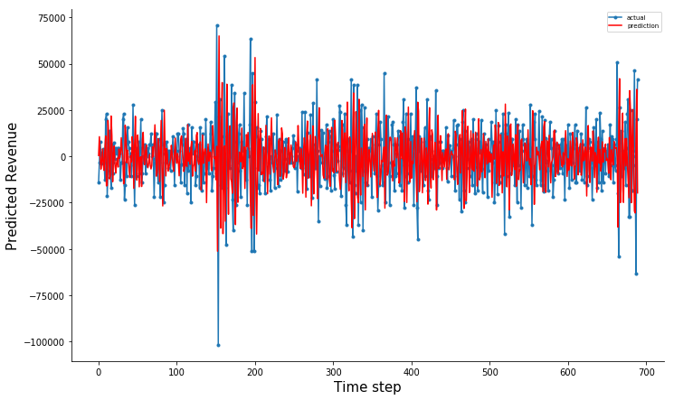

```python
aa=[x for x in range(690)]
plt.figure(figsize=(10,6))
plt.plot(aa, Y_test[0][:690], marker='.', label="actual")
plt.plot(aa, test_predict[:,0][:690], 'r', label="prediction")
plt.tight_layout()
sns.despine(top=True)
plt.subplots_adjust(left=0.07)
plt.ylabel('Predicted Revenue', size=15)
plt.xlabel('Time step', size=15)
plt.legend(fontsize=7)
plt.show()
```

### Conclusions

- I think LSTM did a pretty okay picture
- But, if I could consider a bigger dataset it might give out better results.